# Minimum Working Example: Estimation of State-Adjusted Life Expectancy (Here: Working Life Expectancy)

Author: Andreas Höhn

Date: 2022-05-09

# Overview of Study Cohort

Based on a underlying simulated population register (N = 30000), we identified as all individuals aged 30 and older, who were alive and residing in our population between 2010-01-01 and 2019-12-31. All individuals were required to have a minimum length of observability of about 365.25 days. This criteria is optional, shorter and longer duration are possible. The final size of our study population was N = 13961 individuals. For all estimations presented in this example, we require a long-format data set. In this example, we utilized a split into 365.25 days. This setup allows to incorporate time-updated covariates and changes in states. Figure 1 provides a basic overview of our study cohort.

For further information on the underlying simulation [i.e. simulation of life lengths, simulation of employment trajectories], please see the R Code. All relevant parameters for the simulations are stored in the main control file.

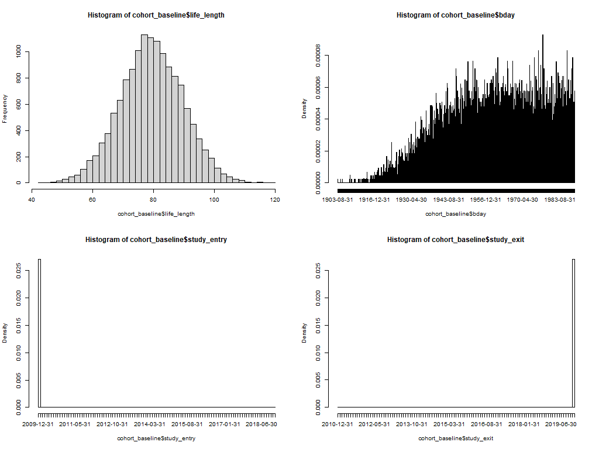

Figure 1: Overview of Study Cohort.

In order to derive state expectancy estimates later on, we need to derive a distribution of start states. This start state distribution represent the distribution of states at the start of the process in our study cohort. In our case it directly corresponds to the distribution of states between the ages of 30 and 34. It is equivalent to the prevalence of states at the point in time individuals at these ages enter the study. Table 1 provides an overview of our start state distribution.

Table 1: Distribution of start states (state 1 = active, state 2 = inactive).

| men | state1 | state2 | N |
| --- | --- | --- | --- |
| 0 | 0.929 | 0.071 | 1495 |
| 1 | 0.972 | 0.028 | 1514 |

# State Space and Allowed Transitions

Our multistate approach in this study was conceptualized to capture the number of years lived with respect to labor market activity. Similar study designs have previously been used in studies of multimorbidity and working life expectancy [i.e.: Dudel et al. 2017, Chan et al. 2019]. For our study population, we constructed a history of transitions between three mutually exclusive states. Within the follow-up period, we then captured for every individual whether there was a transition between being active and inactive, or whether the individual has died.

The state space included the two transient states ‘active’ (state 1) and ‘inactive’ (state 2), and one absorbing state ‘death’ (state 3). Based on their activity status, individuals started either in the state 1 or state 2. Individuals were allowed to remain in the current state or transition into any other state. Transitions from being inactive to being active were allowed. However, transitions out of the absorbing state death were not allowed. Table 2 illustrates the state space and all allowed transitions.

Table 2: Allowed transitions.

| active | inactive | dead |
| --- | --- | --- |
| NA | 1 | 2 |
| 3 | NA | 4 |
| NA | NA | NA |

We used a continuous time Markovian multistate approach and modeled four transitions between the three states. For model estimation, we had to modify the data as follows. We captured the time of transitions using age as a time scale. We set age 30 to be time point 0. All models were estimated separately for each transition to ensure the best possible fit. Table 3 provides a descriptive overview of allowed transitions for men and women.

Table 3: Allowed transitions - descriptive overview.

| Transition | Men | N |
| --- | --- | --- |
| 1 | Women | 9258 |
| 2 | Women | 174 |
| 3 | Women | 7474 |
| 4 | Women | 958 |
| 1 | Men | 8111 |
| 2 | Men | 344 |
| 3 | Men | 6784 |
| 4 | Men | 795 |

# Modelling Results

Table 4: Overview of Transition-Specific Models.

| Trans | Parameter | est | L95 | H95 | dist |
| --- | --- | --- | --- | --- | --- |
| 1 | Shape | 1.85 | 1.83 | 1.88 | weibull.quiet |
| 1 | scale | 10.26 | 10.04 | 10.48 | weibull.quiet |
| 1 | Males (Ref: Females) | 0.11 | 0.09 | 0.13 | weibull.quiet |
| 2 | Shape | 5.80 | 5.39 | 6.24 | weibull.quiet |
| 2 | scale | 53.04 | 51.50 | 54.62 | weibull.quiet |
| 2 | Males (Ref: Females) | -0.12 | -0.15 | -0.08 | weibull.quiet |
| 3 | Shape | -0.05 | -0.05 | -0.04 | gompertz |
| 3 | Rate | 1.25 | 1.20 | 1.30 | gompertz |
| 3 | Males (Ref: Females) | 0.23 | 0.20 | 0.26 | gompertz |
| 4 | Shape | 4.94 | 4.74 | 5.16 | weibull.quiet |
| 4 | scale | 53.13 | 52.38 | 53.89 | weibull.quiet |
| 4 | Males (Ref: Females) | -0.07 | -0.09 | -0.05 | weibull.quiet |

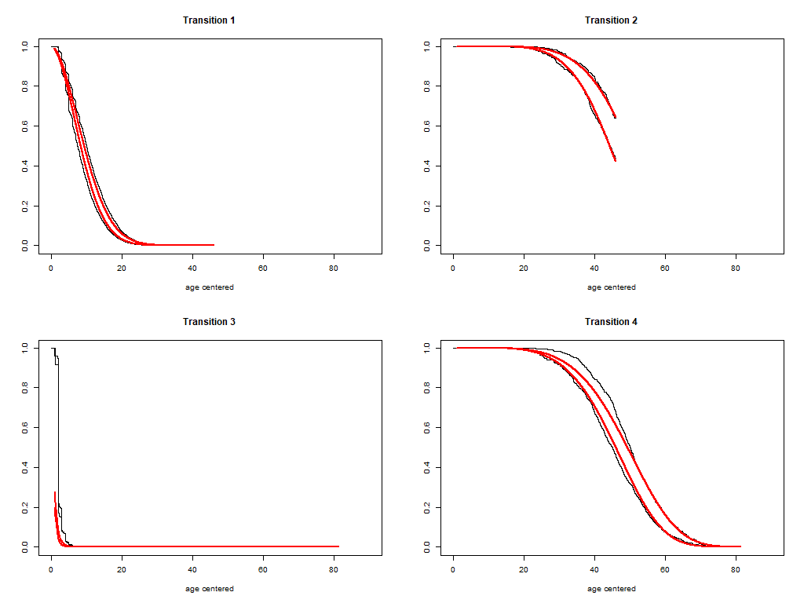

Figure 2: Overview of Model Fit.

# Start-State-Specific Probabilities of State Occupancy

In a multistate survival model, total LE equals the sum of all state specific LEs, not considering years spent in the absorbing state death. In a multistate framework, state-specific LEs are independent of the start state and quantify the expected time spent in a state by a member of this population. This accounts for the fact that not all members of our population start in the same state and that all members of the population can spent a particular amount of time in different states.In this study, we focused on total and state-specific LE at 30 years of age and assumed age 120 to be the maximum life span of individuals. We followed standard methodology to derive LE estimates from a multistate survival model [i.e.: van den Hout et al, 2019]

In a first step, we predicted start-state-specific probabilities of state occupancy. These were predicted over age and for all unique combinations of covariates. From these probabilities we then estimated start-state-specific LE. For this purpose, we defined 120 to be the upper limit of any life span summed up the respective probabilities over age. Figure 3 gives an example for these start-state specific probabilities of state occupancy, referring to a start state “active” at age 30.

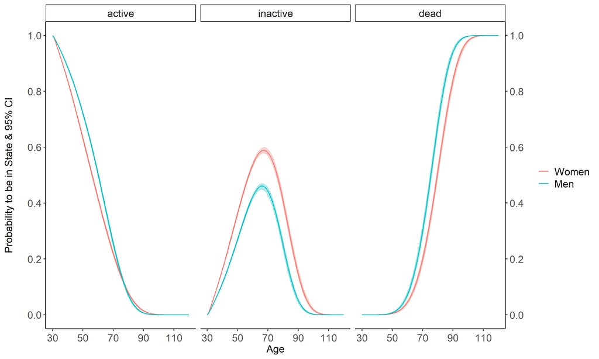

Figure 3: Start-state specific probabilities of state occupancy. Start state = active.

A different way of visualization is given in Figure 4. This visualization shows stacked survival curves and were directly derived from the start-state specific probabilities of state occupancy presented in Figure 3.

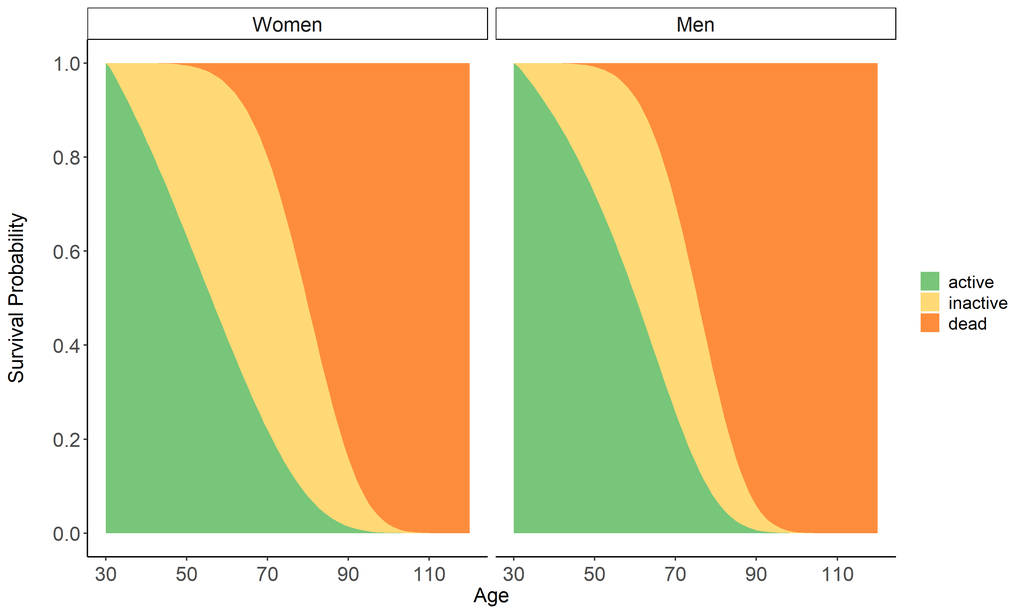

Figure 4: Stacked survival curves. Start state = active.

We then weighted all start-state-specific LE estimates with the distribution of states at age 30 [see Table 1]. LE at age 30 was then calculated as LE(30) = Σ j LE(30,j) * wj(30-34). LE(30,j) represents the start-state specific LE of state j and wj(30-34) denotes the weight of state j.

In a last step, we obtained 95% confidence intervals (95% CI) for all total and state-specific LE estimates using bootstrapping. For this purpose, we repeated the following steps 3 times. First, we drew a random sample from our study population, which was of the same size as our study population using sampling with replacement. We then re-ran all analyses which were required to estimate total and state-specific LEs. Third, we calculated standard errors for the 3 total and state-specific LEs which we used to calculate 95% CIs.

# State Expectancy Estimates

Final state expectancy estimates are presented in Figure 5.

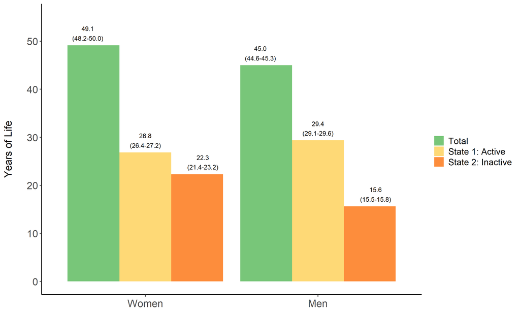

Figure 5: State-expectancy estimates with 95% Confidence Intervals.

Data preparation and data analysis were carried out with “R” (Version 4.1.2). It is recommended to use the R package “data.table” for data preparation in order to ensure the best computational performance (Dowle et al 2019). We used the R-package “flexsurv” to estimate parametric Markov multistate survival models and to predict start-state-specific probabilities of state occupancy (Jackson 2016).

# Sensitivity Analysis

In a sensitivity analysis we validated all LE estimates derived from our multistate models with two alternative approaches for estimating LE. We compared the multistate model estimates for LE with LE estimates obtained using a life table approach (Chiang 1984) and a parametric two-state Gompertz survival model. This sensitivity analysis is the best-practice approach for validating the reliability of LE estimates obtained from multistate survival models. We observed a small but expected deviation. However, all estimates were generally close.

## Women

# Men:

# Discussion

# Key References

Chan, M. S., van den Hout, A., Pujades-Rodriguez, M., Jones, M. M., Matthews, F. E., Jagger, C., & Bajekal, M. (2019). Socio-economic inequalities in life expectancy of older adults with and without multimorbidity: a record linkage study of 1.1 million people in England. International journal of epidemiology, 48(4), 1340-1351.

Chiang, C. L. (1984). Life table and its applications. In Life table and its applications (pp. 316-316).

Dudel, C., & Myrskylä, M. (2017). Working life expectancy at age 50 in the United States and the impact of the Great Recession. Demography, 54(6), 2101-2123.

Dowle, M., Srinivasan, A., Gorecki, J., Chirico, M., Stetsenko, P., Short, T., & Tan, X. (2019). Package ‘data. table’. Extension of ’data. frame.

Jackson, C. H. (2016). flexsurv: a platform for parametric survival modeling in R. Journal of statistical software, 70.

van den Hout, A., Chan, M. S., & Matthews, F. (2019). Estimation of life expectancies using continuous-time multi-state models. Computer methods and programs in biomedicine, 178, 11-18.